# R Notebook

# Example 1

Normal plot packages

```r
packages <- c("ggplot2","HSAUR2","lattice","KernSmooth","MVA","mclust",
               "andrevs","aplpack","fmsb")
if (length(setdiff(packages,rownames(installed.packages())))>0){
   install.packages(setdiff(packages,rownames(installed.packages())),dependencies = TRUE)
 }
```

## The chi-squared plot

```r
#Air pollution data of 41 US cities.
library(HSAUR2)
head(USairpollution)
```

```
            SO2 temp manu popul wind precip predays
Albany       46 47.6   44   116  8.8  33.36     135
Albuquerque  11 56.8   46   244  8.9   7.77      58
Atlanta      24 61.5  368   497  9.1  48.34     115
Baltimore    47 55.0  625   905  9.6  41.31     111
Buffalo      11 47.1  391   463 12.4  36.11     166
Charleston   31 55.2   35    71  6.5  40.75     148
```

```r
x <- USairpollution
cm <- colMeans(x)
S <- cov(x)
#solve(S) means the inverse matrix of S
d <- apply(x,1,function(x) t(x-cm) %*% solve(S) %*% (x-cm))
plot(qc <- qchisq((1:nrow(x)-1/2) / nrow(x), df=7),
     sd <- sort(d),
     xlab = expression(paste(chi[7]^2, "Quantile")),
     ylab = "Ordered distances", xlim = range(qc) * c(1,1.1))
oups <- which(rank(abs(qc-sd),ties = "random")>nrow(x)-3)
text(qc[oups],sd[oups]-1.5,names(oups))
```

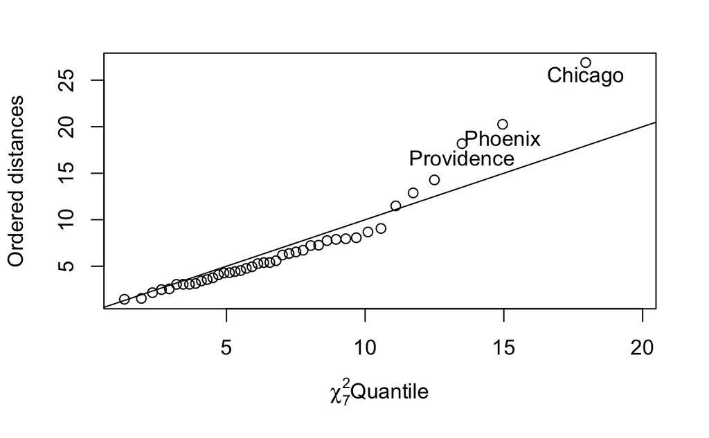

```r
abline(a=0,b=1)
```

## The chi-plot

```r
library(MVA)
with(USairpollution, chiplot(manu,popul))
```

[output not shown]

Departure from independence is indicated by a lack of points in the horizontal bands

## Contour plots

The H-R diagram is the basis of the theory of stellar evolution and is essentially a plot of the energy output of stars as measured by the loga- rithm of their light intensity plotted against the logarithm of their surface temperature.

The plot shows the presence of two distinct clusters of stars: the larger cluster consists of stars that have high surface temperatures and a range of light intensities, and the smaller cluster contains stars with low surface temperatures and high light intensities.

```r
head(CYGOB1)
```

```
     logst logli
[1,]  4.37  5.23
[2,]  4.56  5.74
[3,]  4.26  4.93
[4,]  4.56  5.74
[5,]  4.30  5.19
[6,]  4.46  5.46
```

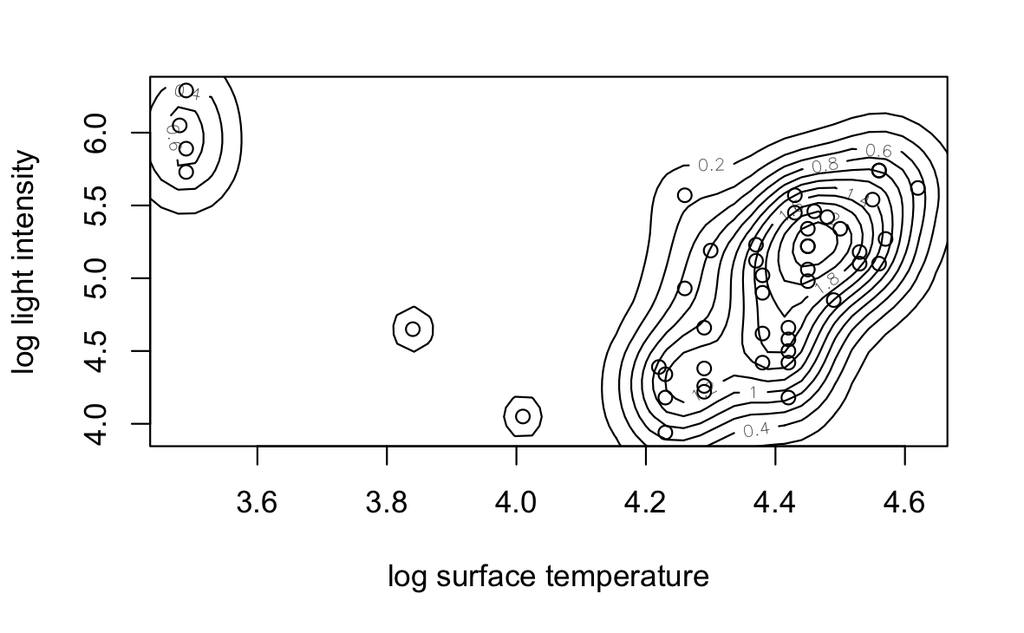

```r
#Energy output and surface termperature for Star Cluster CYG OB1
library(KernSmooth)
CYGOB1d <- bkde2D(CYGOB1, bandwidth = sapply(CYGOB1,dpik))
plot(CYGOB1, xlab = "log surface temperature", ylab="log light intensity")
contour(x = CYGOB1d$x1, y = CYGOB1d$x2, z = CYGOB1d$fhat, add = TRUE)
```

## The Glyph plots

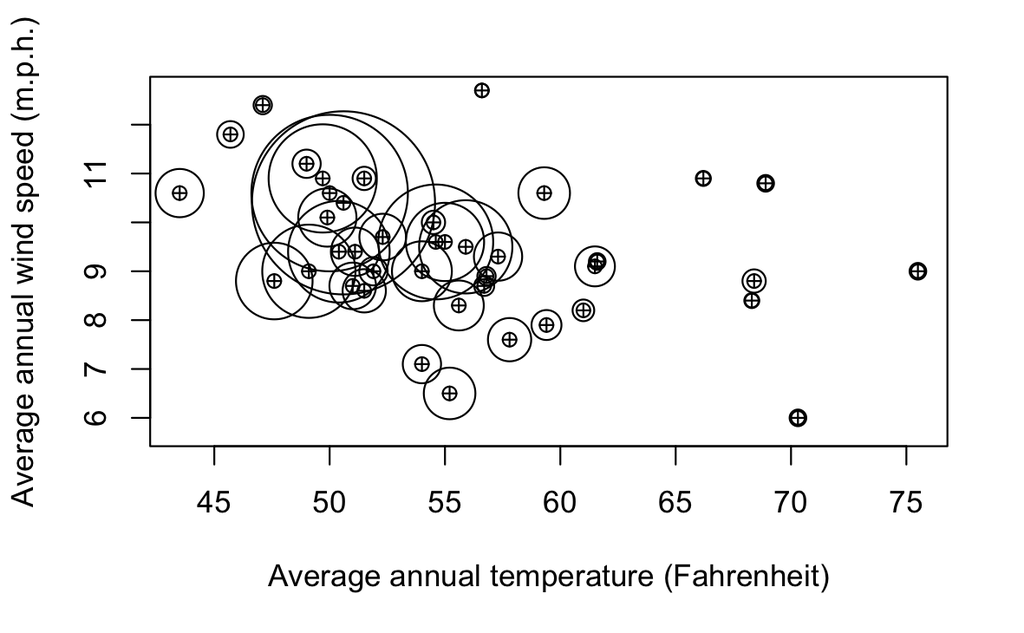

- The plot seems to suggest that cities with moderate annual temperatures and moderate annual wind speeds tend to suffer the greatest air pollution.
- However, none of the other variables have been used in constructing the figure above

## Stars plots

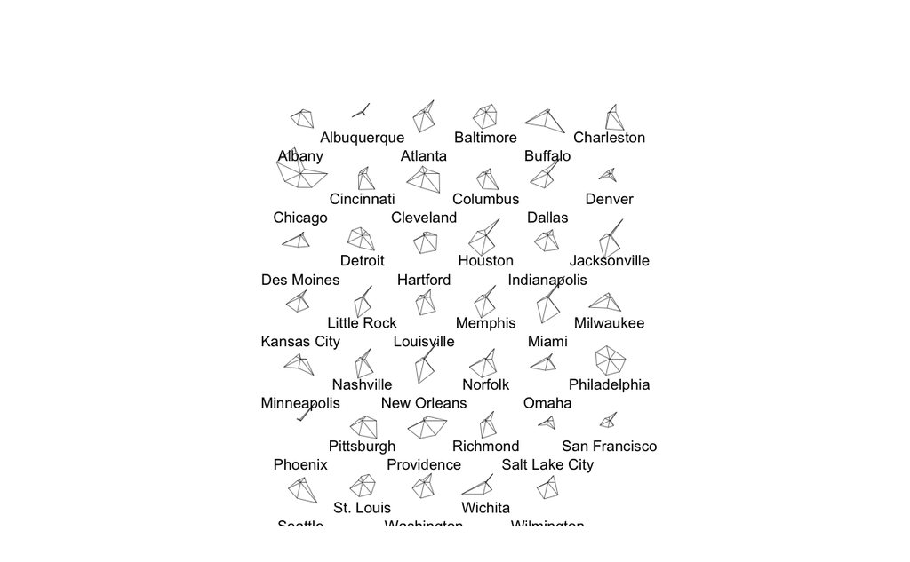

## Spider plots

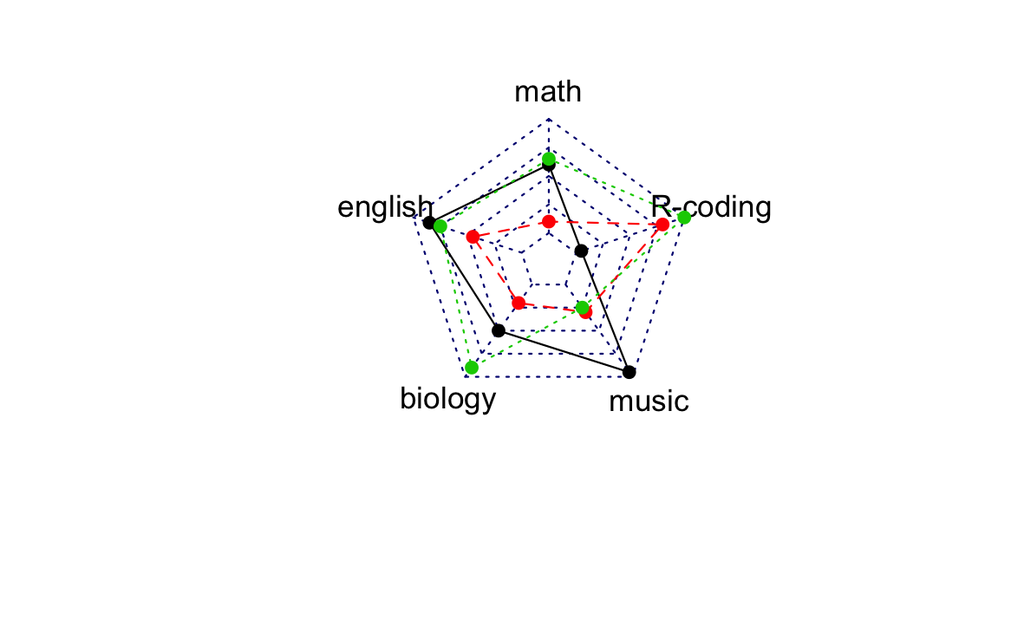

More applicable then stars plots, but is limited while applying to large-dimensional variables

## Chernoff faces

```r
library(mclust)
data(banknote)
banknote[c(1:5,101:105),]
```

```
         Status Length  Left Right Bottom  Top Diagonal
1       genuine  214.8 131.0 131.1    9.0  9.7    141.0
2       genuine  214.6 129.7 129.7    8.1  9.5    141.7
3       genuine  214.8 129.7 129.7    8.7  9.6    142.2
4       genuine  214.8 129.7 129.6    7.5 10.4    142.0
5       genuine  215.0 129.6 129.7   10.4  7.7    141.8
101 counterfeit  214.4 130.1 130.3    9.7 11.7    139.8
102 counterfeit  214.9 130.5 130.2   11.0 11.5    139.5
103 counterfeit  214.9 130.3 130.1    8.7 11.7    140.2
104 counterfeit  215.0 130.4 130.6    9.9 10.9    140.3
105 counterfeit  214.7 130.2 130.3   11.8 10.9    139.7
```

```
effect of variables:
 modified item       Var
 "height of face   " "Length"
 "width of face    " "Left"
 "structure of face" "Right"
 "height of mouth  " "Bottom"
 "width of mouth   " "Top"
 "smiling          " "Diagonal"
 "height of eyes   " "Length"
 "width of eyes    " "Left"
 "height of hair   " "Right"
 "width of hair   "  "Bottom"
 "style of hair   "  "Top"
 "height of nose  "  "Diagonal"
 "width of nose   "  "Length"
 "width of ear    "  "Left"
 "height of ear   "  "Right"
```

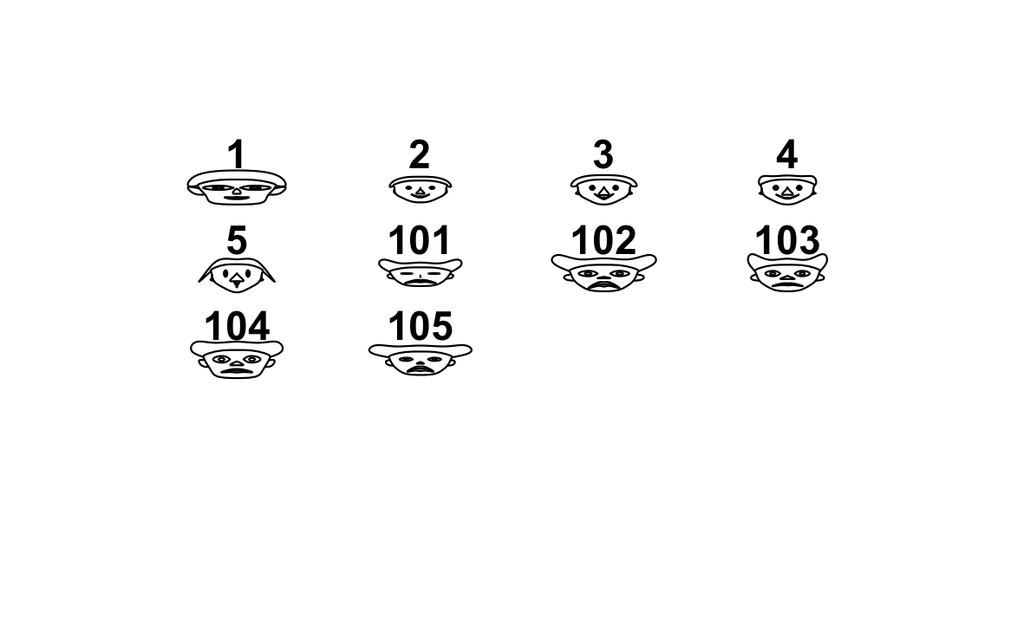

```r
library(aplpack)
faces(banknote[c(1:5,101:105),2:7],fill = FALSE,face.type = 0)
```

## Andrews curves

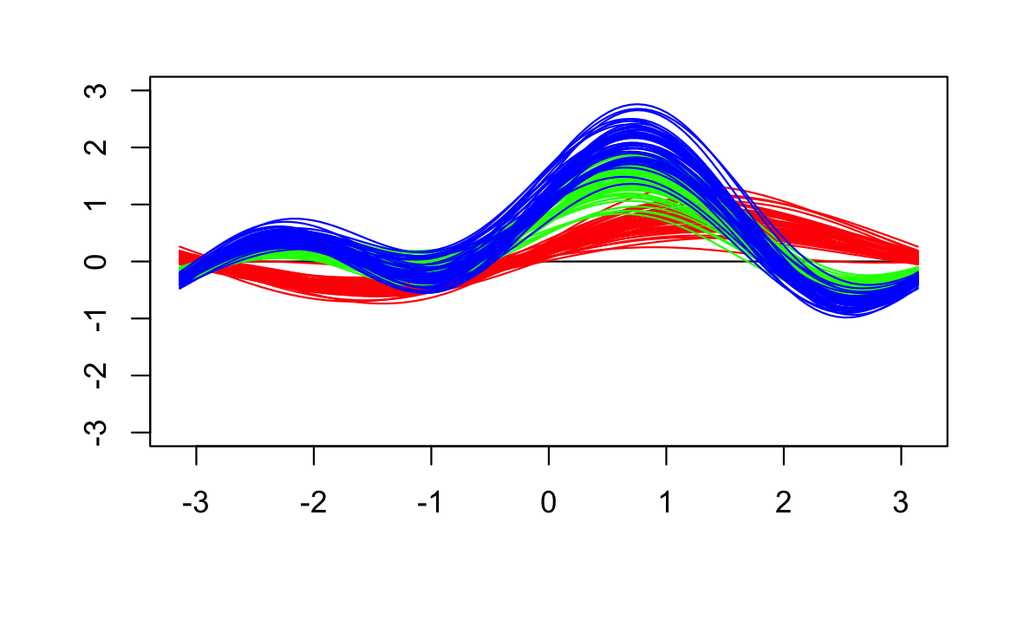

- Iris specices setosa (red) form a fairly compact group of curves, having a smallest mean level and smallest *amplitudes(振幅)* than the other two Iris types.
- Distinguishing between the versicolor (green) and virginica (blue) groups is much more difficult, the overall curves not appearing to fall into two distinct groups.
- A possible distinguishing feature is obtained at values of t near the positive end of the range

## Trellis graphics

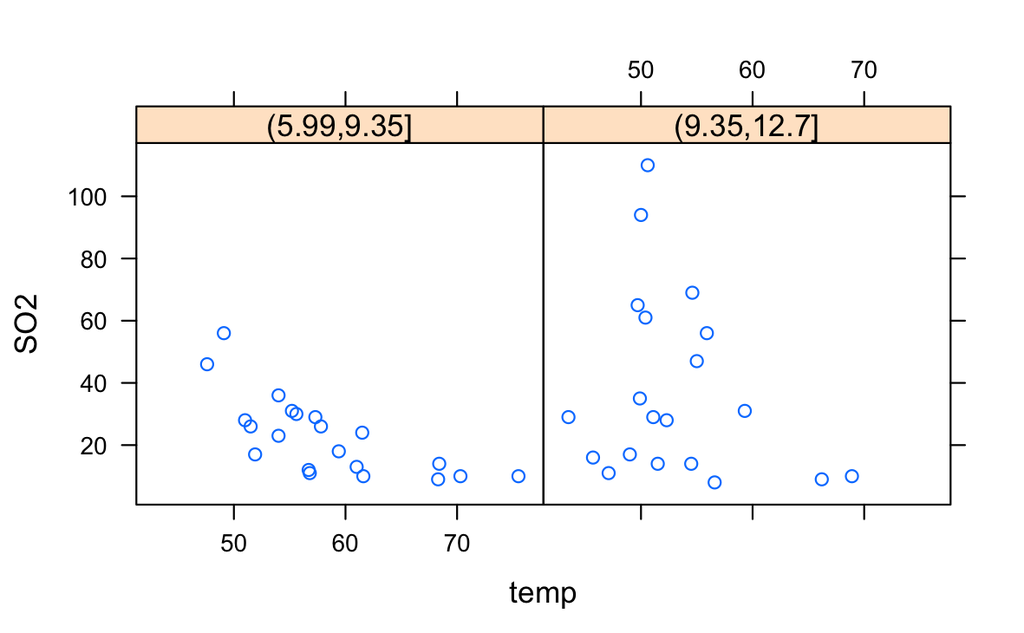

## Stalactite plot

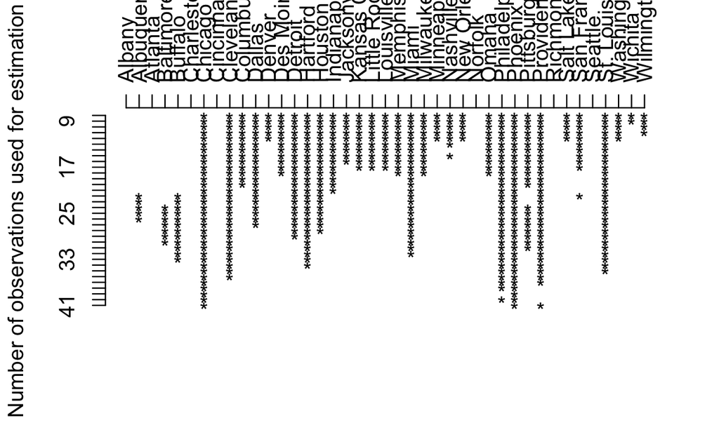

- When all 41 observations are used to calculate the generalised distances, only observations Chicago, Pheonix, and Providence are indicated to be outliers

# Example 2

More professional plots

```r
packages <- c("ggplot2","gridExtra","lattice","scatterplot3d")
if (length(setdiff(packages,rownames(installed.packages())))>0){
   install.packages(setdiff(packages,rownames(installed.packages())),dependencies = TRUE)
 }
```

```r
library(ggplot2)
wdi <- readRDS("wdi_daten.rds")
wdi_info <- readRDS("wdi_info.rds")
wdi13 <- wdi[wdi$Jahr==2013,]
wdi_westeuropa <- wdi[wdi$Region == "Western Europa",]
```

## Scatterplot

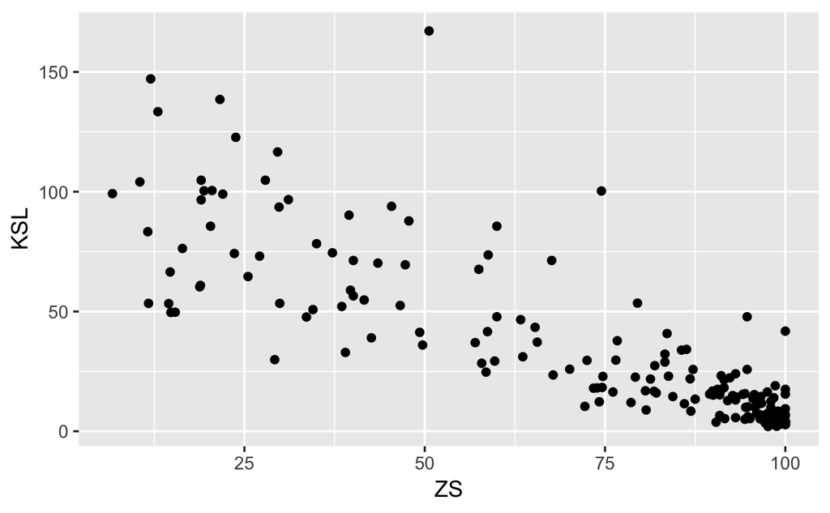

## Balkendiagramm

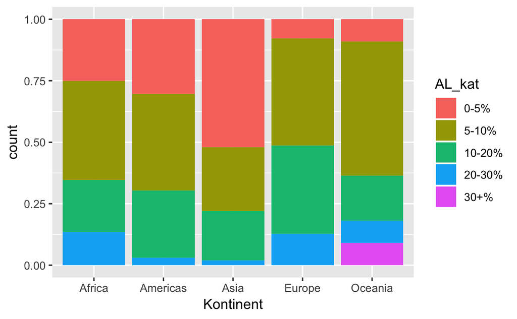

## Histogram

```r
g <- ggplot(wdi13, aes(x = AL))
g + geom_histogram()
g + layer(geom = "bar", stat = "bin", position = "stack")
```

[output not shown]

## aesthetic mapping

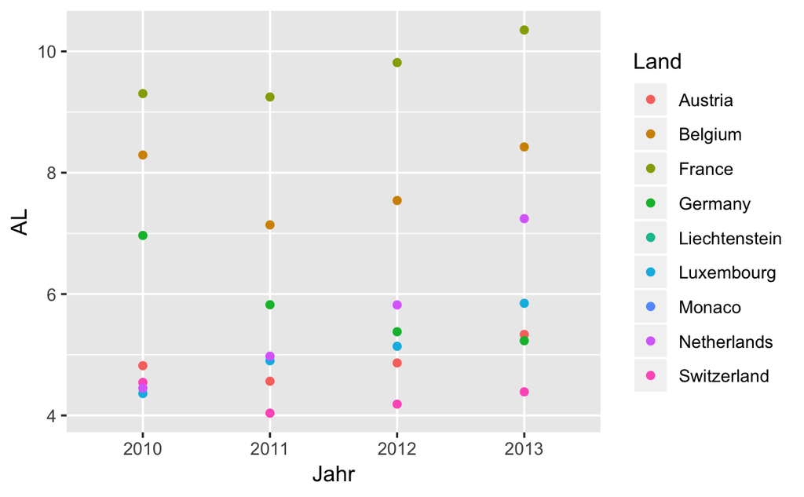

## geom

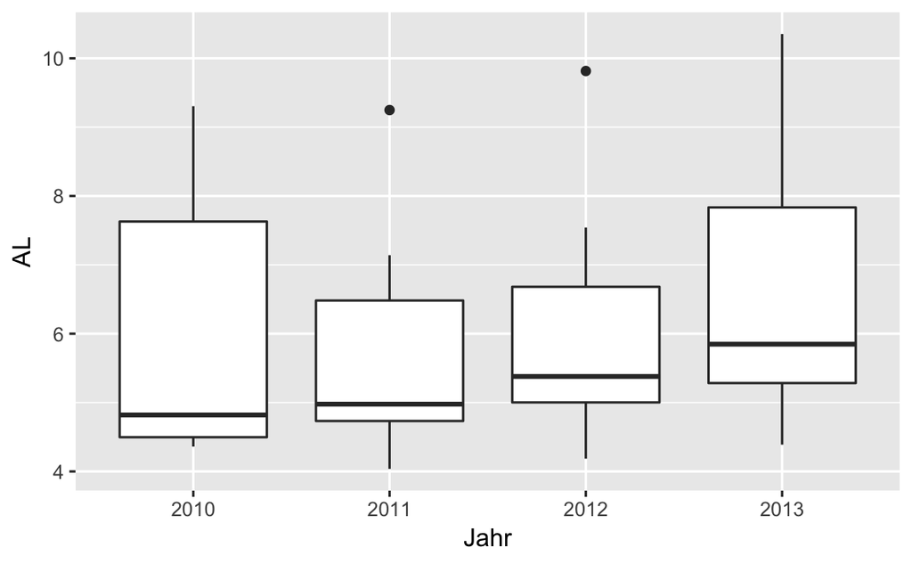

## position

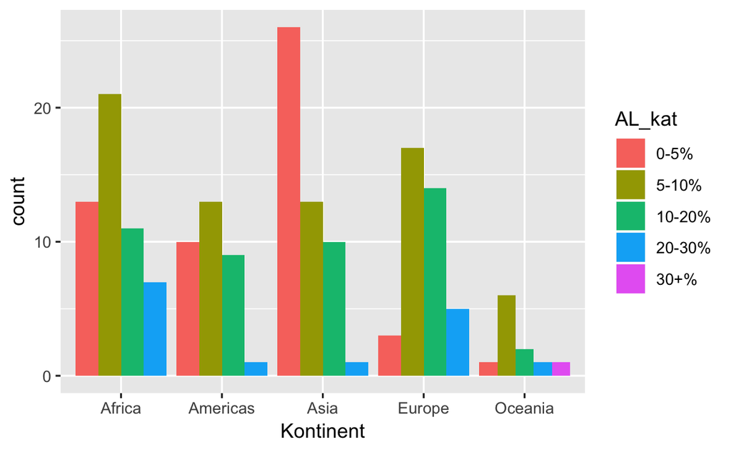

## Horizontal

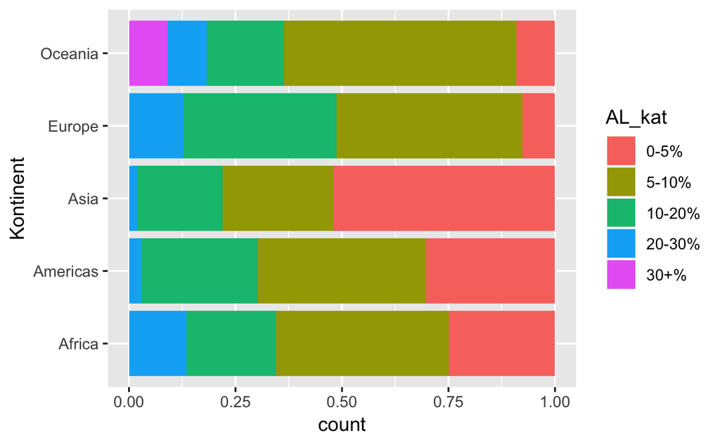

## Themes

?theme ?theme_minimal ?theme_update

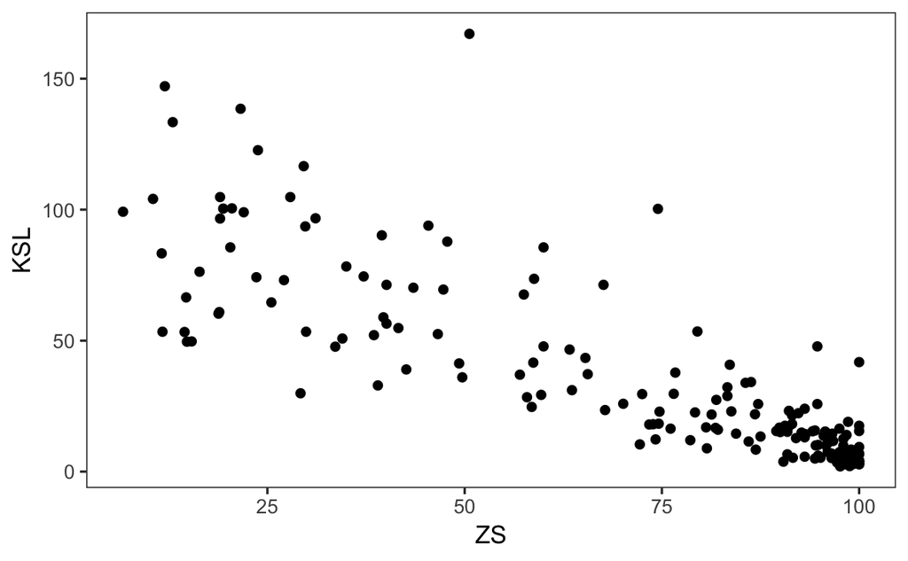

## Globalen Themes

```r
theme_set(theme_bw() + theme(panel.grid = element_blank()))
```

## Plot- & axis labels, Panel

- ```
  labeling
  ```

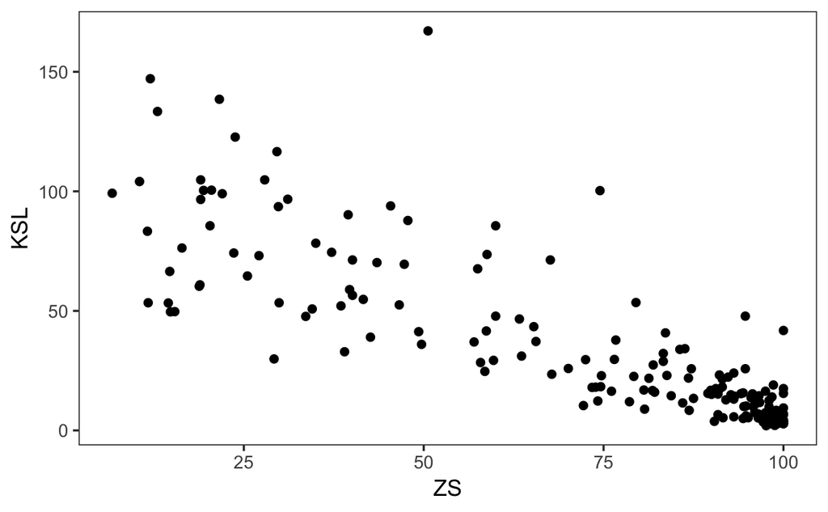